# Assignment 3:

Student name: James/Peng Li

Student ID: 24008144

## Introduction

#### In Assginment 4, we acquired data sets from three different resources:

1. Computer excel file
- Resource: bp Statistical Review of World Energy 2021 | 70th edition
- Data: Energy Consumption per Capita 2010-2020
1. Web API
- Resource: World Bank
- Data: GDP per Capita, CO2 per Capita, Forest Area, Population 2010-2020
1. Web-scraped
- Resource: form on website
- Data: Happiness Indicator 2010-2020

#### We extracted them into follow 6 excel files:

- Data1,energy2010to2020: Energy Consumption per Capita 2010-2020,
- Data2, worldbank_gdp: GDP per Capita 2010-2020
- Data3,worldbank_CO2: CO2 per Capita 2010-2020
- Data4,worldbank_forest: Forest Area 2010-2020
- Data5, worldbank_population: Population 2010-2020
- Data6, happiness: Hapiness 2010-2020

#### Read data into DB and inquires for analysis:

We read in all the data and populate the tables from the notebook into DB. After that we perform some analysis that extracting data from DB. Lastly, we create at least two DB Views which encapsulated queries from above and test them.

#### General analysis logic is still the same as assignment 4, but so detailed as in assignment, with some trails based on data from DB:

- The energy efficiency for GDP. This means for same energy consumption unit which country can achieve higher GDP?
- The energy efficiency for CO2 emission. This means for same energy consumption unit which country can emit less CO2?
- The compensation of forest for CO2 emission. Based on the CO2 emission, does the country have certain forest area to compensate the CO2 emission?

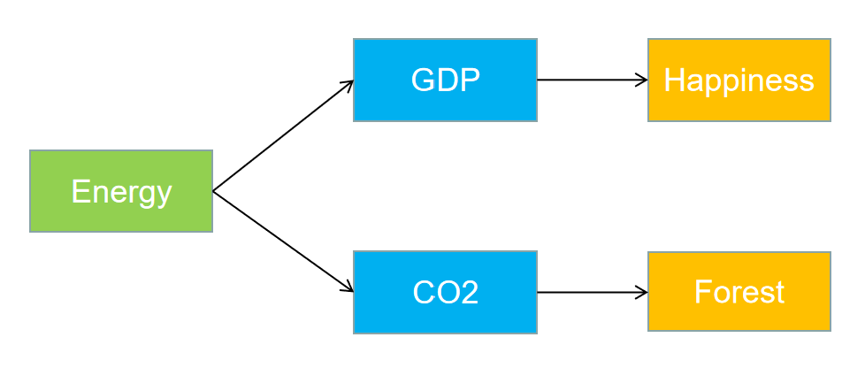

```python
from IPython.display import Image
Image(filename="D:/g.png", width=500, height=200)
```

## Contents

#### 1.Input files acquired from different sources in assignment 4

#### 2.Create a simple DB schema document that shows the tables, and also read 6 files from flat-files and writing data into SQLite tables

2.1 Energy Consumption per Capita 2010-2020

2.2 GDP per Capita 2010-2020

2.3 CO2 per Capita

2.4 Forest Area 2010-2020

2.5 Population 2010-2020

2.6 Happiness Indicator 2010-2020

#### 3.Image file from the schema DB design document

#### 4.Analysis that extractes data from DB

4.1 Energy Consumption per Capita (2010-2020) of 10 Selected Countries

4.2 Average Energy Consumption per Capita (2010-2020) and Ranking

4.3 GDP per Capita (2010-2020) of 10 Selected Countries

4.4 Average GDP per Capita (2010-2020) and GDP Efficiency based on Eenergy

4.5 CO2 per Capita (2010-2020)

4.6 Average CO2 per Capita (2010-2020) and CO2 Emission based on Energy

4.7 Forest per Capita (2010-2020)

#### 5.Analysis that extractes data from DB

5.1 CREATE VIEW NewZealand_happiness

5.2 CREATE VIEW high_happiness_countries_in_2020

```python
import os
import pandas as pd
import numpy as np
import matplotlib
import matplotlib.pyplot as plt
import seaborn as sns
sns.set(style="ticks")
from pylab import rcParams
import pylab
%matplotlib inline
matplotlib.style.use('ggplot')
# Set some Pandas options as you like
pd.set_option('display.notebook_repr_html', True)
#this line enables the plots to be embedded into the notebook
rcParams['figure.figsize'] = 15, 10
rcParams['font.size'] = 20
rcParams['axes.facecolor'] = 'white'
pd.set_option('display.max_columns', None)
#we first need to make some extra imports
import json
from time import sleep
from datetime import datetime
import requests
from bs4 import BeautifulSoup
import pandas as pd
```

# 1. Input files acquired from different sources in assignment 4

- Data1,energy2010to2020: Energy Consumption per Capita 2010-2020,
- Data2, worldbank_gdp: GDP per Capita 2010-2020
- Data3,worldbank_CO2: CO2 per Capita 2010-2020
- Data4,worldbank_forest: Forest Area 2010-2020
- Data5, worldbank_population: Population 2010-2020
- Data6, happiness: Hapiness 2010-2020

```python
energy2010to2020 = pd.read_excel('./energy2010to2020.xls')
energy2010to2020 = pd.DataFrame(energy2010to2020 )
energy2010to2020 = energy2010to2020 .melt(id_vars=['Country_name'], var_name='year', value_name='Energy_consumption_per_capita')
energy2010to2020
```

|  | Country_name | year | Energy_consumption_per_capita |
| --- | --- | --- | --- |
| 0 | Canada | 2010 | 388.8 |
| 1 | Mexico | 2010 | 64.1 |
| 2 | United States | 2010 | 300.7 |
| 3 | Argentina | 2010 | 79.1 |
| 4 | Brazil | 2010 | 56.0 |
| ... | ... | ... | ... |
| 699 | South Korea | 2020 | 229.9 |
| 700 | Sri Lanka | 2020 | 15.3 |
| 701 | Thailand | 2020 | 73.3 |
| 702 | Vietnam | 2020 | 42.0 |
| 703 | South Africa | 2020 | 82.7 |

704 rows × 3 columns

```python
worldbank_gdp = pd.read_excel('./worldbank_gdp.xlsx')
worldbank_gdp = pd.DataFrame(worldbank_gdp)
worldbank_gdp
```

|  | Country_name | countrycode | year | GDP_per_capita |
| --- | --- | --- | --- | --- |
| 0 | Africa Eastern and Southern | AFE | 2020 | 1355.805923 |
| 1 | Africa Eastern and Southern | AFE | 2019 | 1507.982881 |
| 2 | Africa Eastern and Southern | AFE | 2018 | 1558.307482 |
| 3 | Africa Eastern and Southern | AFE | 2017 | 1485.522597 |
| 4 | Africa Eastern and Southern | AFE | 2016 | 1346.152564 |
| ... | ... | ... | ... | ... |
| 2921 | Zimbabwe | ZWE | 2014 | 1407.034291 |
| 2922 | Zimbabwe | ZWE | 2013 | 1408.367810 |
| 2923 | Zimbabwe | ZWE | 2012 | 1290.193957 |
| 2924 | Zimbabwe | ZWE | 2011 | 1082.615773 |
| 2925 | Zimbabwe | ZWE | 2010 | 937.840340 |

2926 rows × 4 columns

```python
worldbank_CO2 = pd.read_excel('./worldbank_CO2.xlsx')
worldbank_CO2 = pd.DataFrame(worldbank_CO2)
worldbank_CO2
```

|  | Country_name | Countrycode | year | CO2_per_capita |
| --- | --- | --- | --- | --- |
| 0 | Africa Eastern and Southern | AFE | 2020 | 0.795420 |
| 1 | Africa Eastern and Southern | AFE | 2019 | 0.915294 |
| 2 | Africa Eastern and Southern | AFE | 2018 | 0.921453 |
| 3 | Africa Eastern and Southern | AFE | 2017 | 0.933874 |
| 4 | Africa Eastern and Southern | AFE | 2016 | 0.941337 |
| ... | ... | ... | ... | ... |
| 2921 | Zimbabwe | ZWE | 2014 | 0.866838 |
| 2922 | Zimbabwe | ZWE | 2013 | 0.901248 |
| 2923 | Zimbabwe | ZWE | 2012 | 0.901214 |
| 2924 | Zimbabwe | ZWE | 2011 | 0.871932 |
| 2925 | Zimbabwe | ZWE | 2010 | 0.741290 |

2926 rows × 4 columns

```python
worldbank_forest = pd.read_excel('./worldbank_forest.xlsx')
worldbank_forest = pd.DataFrame(worldbank_forest)
worldbank_forest
```

|  | Country_name | countrycode | year | ForestArea |
| --- | --- | --- | --- | --- |
| 0 | Africa Eastern and Southern | AFE | 2020 | 4479395.00 |
| 1 | Africa Eastern and Southern | AFE | 2019 | 4511676.20 |
| 2 | Africa Eastern and Southern | AFE | 2018 | 4544314.78 |
| 3 | Africa Eastern and Southern | AFE | 2017 | 4575901.20 |
| 4 | Africa Eastern and Southern | AFE | 2016 | 4607876.10 |
| ... | ... | ... | ... | ... |
| 2921 | Zimbabwe | ZWE | 2014 | 177210.00 |
| 2922 | Zimbabwe | ZWE | 2013 | 177670.70 |
| 2923 | Zimbabwe | ZWE | 2012 | 178131.40 |
| 2924 | Zimbabwe | ZWE | 2011 | 178592.10 |
| 2925 | Zimbabwe | ZWE | 2010 | 179052.80 |

2926 rows × 4 columns

```python
worldbank_population = pd.read_excel('./worldbank_population.xlsx')
worldbank_population = pd.DataFrame(worldbank_population)
worldbank_population
```

|  | Country_name | Countrycode | year | Population |
| --- | --- | --- | --- | --- |
| 0 | Africa Eastern and Southern | AFE | 2020 | 685112979.0 |
| 1 | Africa Eastern and Southern | AFE | 2019 | 667242986.0 |
| 2 | Africa Eastern and Southern | AFE | 2018 | 649757148.0 |
| 3 | Africa Eastern and Southern | AFE | 2017 | 632746570.0 |
| 4 | Africa Eastern and Southern | AFE | 2016 | 616377605.0 |
| ... | ... | ... | ... | ... |
| 2921 | Zimbabwe | ZWE | 2014 | 13855753.0 |
| 2922 | Zimbabwe | ZWE | 2013 | 13555422.0 |
| 2923 | Zimbabwe | ZWE | 2012 | 13265331.0 |
| 2924 | Zimbabwe | ZWE | 2011 | 13025785.0 |
| 2925 | Zimbabwe | ZWE | 2010 | 12839771.0 |

2926 rows × 4 columns

```python
happiness = pd.read_excel('./happiness.xlsx')
happiness = pd.DataFrame(happiness)
happiness
```

|  | Country_name | year | Life_ladder | Log GDP per capita | Social support | Healthy life expectancy at birth | Freedom to make life choices | Generosity | Perceptions of corruption | Positive affect | Negative affect |
| --- | --- | --- | --- | --- | --- | --- | --- | --- | --- | --- | --- |
| 0 | Afghanistan | 2008 | 3.723590 | 7.370100 | 0.450662 | 50.799999 | 0.718114 | 0.167640 | 0.881686 | 0.517637 | 0.258195 |
| 1 | Afghanistan | 2009 | 4.401778 | 7.539972 | 0.552308 | 51.200001 | 0.678896 | 0.190099 | 0.850035 | 0.583926 | 0.237092 |
| 2 | Afghanistan | 2010 | 4.758381 | 7.646709 | 0.539075 | 51.599998 | 0.600127 | 0.120590 | 0.706766 | 0.618265 | 0.275324 |
| 3 | Afghanistan | 2011 | 3.831719 | 7.619532 | 0.521104 | 51.919998 | 0.495901 | 0.162427 | 0.731109 | 0.611387 | 0.267175 |
| 4 | Afghanistan | 2012 | 3.782938 | 7.705479 | 0.520637 | 52.240002 | 0.530935 | 0.236032 | 0.775620 | 0.710385 | 0.267919 |
| ... | ... | ... | ... | ... | ... | ... | ... | ... | ... | ... | ... |
| 1944 | Zimbabwe | 2016 | 3.735400 | 7.984372 | 0.768425 | 54.400002 | 0.732971 | -0.094634 | 0.723612 | 0.737636 | 0.208555 |
| 1945 | Zimbabwe | 2017 | 3.638300 | 8.015738 | 0.754147 | 55.000000 | 0.752826 | -0.097645 | 0.751208 | 0.806428 | 0.224051 |
| 1946 | Zimbabwe | 2018 | 3.616480 | 8.048798 | 0.775388 | 55.599998 | 0.762675 | -0.068427 | 0.844209 | 0.710119 | 0.211726 |
| 1947 | Zimbabwe | 2019 | 2.693523 | 7.950132 | 0.759162 | 56.200001 | 0.631908 | -0.063791 | 0.830652 | 0.716004 | 0.235354 |
| 1948 | Zimbabwe | 2020 | 3.159802 | 7.828757 | 0.717243 | 56.799999 | 0.643303 | -0.008696 | 0.788523 | 0.702573 | 0.345736 |

1949 rows × 11 columns

# 2. Create a simple DB schema document that shows the tables, and also read 6 files from flat-files and writing data into SQLite tables

```python
from IPython.core.display import display, HTML
display(HTML("<style>.container { width:100% !important; }</style>"))
```

```python
%load_ext sql
```

```
The sql extension is already loaded. To reload it, use:
  %reload_ext sql
```

```python
%sql sqlite:///../datasets/mySQLiteTransactionDB.db3
```

[output not shown]

[output cut: 53 more lines]

[output not shown]

```python
import pandas as pd
import sqlite3
import numpy as np
import matplotlib
import matplotlib.pyplot as plt
from pylab import rcParams

rcParams['figure.figsize'] = 15, 10
rcParams['font.size'] = 20
rcParams['axes.facecolor'] = 'white'

%matplotlib inline
%sql sqlite:///../datasets/StudentDB.db3 PRAGMA foreign_keys = ON;
```

[output not shown]

[output cut: 53 more lines]

[output not shown]

```python
connection = sqlite3.connect('./datasets/mySQLiteDB.sl3')
cursor = connection.cursor()
```

## 2.1 Energy Consumption per Capita 2010-2020

```python
energy2010to2020 .head(1)
```

|  | Country_name | year | Energy_consumption_per_capita |
| --- | --- | --- | --- |
| 0 | Canada | 2010 | 388.8 |

```python
cursor.execute('DROP TABLE IF EXISTS energy2010to2020')

table = """
            CREATE TABLE energy2010to2020 (
        Country_name VARCHAR(20) NOT NULL,
        year INTEGER NOT NULL,
        Energy_consumption_per_capita NUMBER NOT NULL,
        PRIMARY KEY (Country_name, year))
            """
cursor.execute(table)
```

```
<sqlite3.Cursor at 0x29bfbd27b40>
```

```python
add_row_energy2010to2020 = """
                            INSERT INTO energy2010to2020
                            VALUES (?, ?, ?)
                        """
```

```python
energy2010to2020
```

|  | Country_name | year | Energy_consumption_per_capita |
| --- | --- | --- | --- |
| 0 | Canada | 2010 | 388.8 |
| 1 | Mexico | 2010 | 64.1 |
| 2 | United States | 2010 | 300.7 |
| 3 | Argentina | 2010 | 79.1 |
| 4 | Brazil | 2010 | 56.0 |
| ... | ... | ... | ... |
| 699 | South Korea | 2020 | 229.9 |
| 700 | Sri Lanka | 2020 | 15.3 |
| 701 | Thailand | 2020 | 73.3 |
| 702 | Vietnam | 2020 | 42.0 |
| 703 | South Africa | 2020 | 82.7 |

704 rows × 3 columns

```python
for index, row in energy2010to2020.iterrows():
    substitution_values = (row['Country_name'], row['year'], row['Energy_consumption_per_capita'])
    cursor.execute(add_row_energy2010to2020, substitution_values)

connection.commit()
```

```python
#Check
sql_statement = 'SELECT * FROM energy2010to2020;'
cursor.execute(sql_statement)


for (Country_name, year, Energy_consumption_per_capita) in cursor:
    print(Country_name, year, Energy_consumption_per_capita)
```

```
Canada 2010 388.8
Mexico 2010 64.1
United States 2010 300.7
Argentina 2010 79.1
Brazil 2010 56
Chile 2010 77.9
Colombia 2010 31.8
Ecuador 2010 36.8
Peru 2010 28
Trinidad & Tobago 2010 633.9
Venezuela 2010 118.2
Austria 2010 175.7
Belgium 2010 252.6
Czech Republic 2010 174.3
Finland 2010 242.8
France 2010 169.4
Germany 2010 169.6
Greece 2010 123.1
Hungary 2010 99.8
Italy 2010 122.6
Netherlands 2010 245.5
Norway 2010 354
Poland 2010 109.1
Portugal 2010 101.7
Romania 2010 69.4
Spain 2010 129.5
Sweden 2010 229.8
Switzerland 2010 157.4
Turkey 2010 62.2
Ukraine 2010 111.3
United Kingdom 2010 140.5
Azerbaijan 2010 51.9
Belarus 2010 115.6
Kazakhstan 2010 137.5
Russian Federation 2010 195.1
Turkmenistan 2010 176.6
Uzbekistan 2010 66
Iran 2010 118.2
Iraq 2010 48.8
Israel 2010 135
```

[output cut: 649 more lines]

```
Bangladesh 2020 9.7
China 2020 101.1
India 2020 23.2
Indonesia 2020 29.6
Japan 2020 134.7
Malaysia 2020 127.1
New Zealand 2020 174.3
Pakistan 2020 15.7
Philippines 2020 16.7
Singapore 2020 583.9
South Korea 2020 229.9
Sri Lanka 2020 15.3
Thailand 2020 73.3
Vietnam 2020 42
South Africa 2020 82.7
```

## 2.2 GDP per Capita 2010-2020

```python
worldbank_gdp = worldbank_gdp.dropna(subset=['GDP_per_capita'])
worldbank_gdp
```

|  | Country_name | countrycode | year | GDP_per_capita |
| --- | --- | --- | --- | --- |
| 0 | Africa Eastern and Southern | AFE | 2020 | 1355.805923 |
| 1 | Africa Eastern and Southern | AFE | 2019 | 1507.982881 |
| 2 | Africa Eastern and Southern | AFE | 2018 | 1558.307482 |
| 3 | Africa Eastern and Southern | AFE | 2017 | 1485.522597 |
| 4 | Africa Eastern and Southern | AFE | 2016 | 1346.152564 |
| ... | ... | ... | ... | ... |
| 2921 | Zimbabwe | ZWE | 2014 | 1407.034291 |
| 2922 | Zimbabwe | ZWE | 2013 | 1408.367810 |
| 2923 | Zimbabwe | ZWE | 2012 | 1290.193957 |
| 2924 | Zimbabwe | ZWE | 2011 | 1082.615773 |
| 2925 | Zimbabwe | ZWE | 2010 | 937.840340 |

2843 rows × 4 columns

```python
worldbank_gdp.rename(columns={'countrycode': 'Countrycode'}, inplace=True)
```

```python
worldbank_gdp.head(1)
```

|  | Country_name | Countrycode | year | GDP_per_capita |
| --- | --- | --- | --- | --- |
| 0 | Africa Eastern and Southern | AFE | 2020 | 1355.805923 |

```python
print (worldbank_gdp.info())
```

```
<class 'pandas.core.frame.DataFrame'>
Index: 2843 entries, 0 to 2925
Data columns (total 4 columns):
 #   Column          Non-Null Count  Dtype
---  ------          --------------  -----
 0   Country_name    2843 non-null   object
 1   Countrycode     2799 non-null   object
 2   year            2843 non-null   int64
 3   GDP_per_capita  2843 non-null   float64
dtypes: float64(1), int64(1), object(2)
memory usage: 111.1+ KB
None
```

```python
cursor.execute('DROP TABLE IF EXISTS worldbank_gdp')

table = """
           CREATE TABLE worldbank_gdp (
        Country_name VARCHAR(20) NOT NULL,
        Countrycode VARCHAR(5),
        year INTEGER NOT NULL,
        GDP_per_capita FLOAT NOT NULL,
        PRIMARY KEY (Country_name, year),
        FOREIGN KEY (Country_name, year) REFERENCES energy2010to2020(Country_name, year))
            """
cursor.execute(table)
```

```
<sqlite3.Cursor at 0x29bfbd27b40>
```

```python
add_row_worldbank_gdp = """
    INSERT INTO worldbank_gdp(Country_name, Countrycode, year,GDP_per_capita)
    VALUES (?, ?, ?, ?)
"""
```

```python
worldbank_gdp
```

|  | Country_name | Countrycode | year | GDP_per_capita |
| --- | --- | --- | --- | --- |
| 0 | Africa Eastern and Southern | AFE | 2020 | 1355.805923 |
| 1 | Africa Eastern and Southern | AFE | 2019 | 1507.982881 |
| 2 | Africa Eastern and Southern | AFE | 2018 | 1558.307482 |
| 3 | Africa Eastern and Southern | AFE | 2017 | 1485.522597 |
| 4 | Africa Eastern and Southern | AFE | 2016 | 1346.152564 |
| ... | ... | ... | ... | ... |
| 2921 | Zimbabwe | ZWE | 2014 | 1407.034291 |
| 2922 | Zimbabwe | ZWE | 2013 | 1408.367810 |
| 2923 | Zimbabwe | ZWE | 2012 | 1290.193957 |
| 2924 | Zimbabwe | ZWE | 2011 | 1082.615773 |
| 2925 | Zimbabwe | ZWE | 2010 | 937.840340 |

2843 rows × 4 columns

```python
for index, row in worldbank_gdp.iterrows():
        substitution_values = (row['Country_name'], row['Countrycode'], row['year'], row['GDP_per_capita'])
        cursor.execute(add_row_worldbank_gdp, substitution_values)

connection.commit()
```

```python
#Check
sql_statement = 'SELECT * FROM worldbank_gdp;'
cursor.execute(sql_statement)
for (Country_name,Countrycode, year, GDP_per_capita) in cursor:
    print(Country_name,Countrycode,year, GDP_per_capita)
```

```
Africa Eastern and Southern AFE 2020 1355.80592347323
Africa Eastern and Southern AFE 2019 1507.98288075295
Africa Eastern and Southern AFE 2018 1558.30748213078
Africa Eastern and Southern AFE 2017 1485.52259704758
Africa Eastern and Southern AFE 2016 1346.15256443722
Africa Eastern and Southern AFE 2015 1498.73823019655
Africa Eastern and Southern AFE 2014 1678.55497740355
Africa Eastern and Southern AFE 2013 1696.34288978916
Africa Eastern and Southern AFE 2012 1727.355803856
Africa Eastern and Southern AFE 2011 1763.27867224295
Africa Eastern and Southern AFE 2010 1627.40988133821
Africa Western and Central AFW 2020 1688.07557525957
Africa Western and Central AFW 2019 1812.44682219421
Africa Western and Central AFW 2018 1735.37491121143
Africa Western and Central AFW 2017 1590.27775355217
Africa Western and Central AFW 2016 1648.76267571999
Africa Western and Central AFW 2015 1882.26403755398
Africa Western and Central AFW 2014 2248.31625468362
Africa Western and Central AFW 2013 2154.15083235085
Africa Western and Central AFW 2012 1957.91778421768
Africa Western and Central AFW 2011 1861.38106764835
Africa Western and Central AFW 2010 1679.88782968089
Arab World ARB 2020 5644.14257047661
Arab World ARB 2019 6504.78963270487
Arab World ARB 2018 6579.41710451234
Arab World ARB 2017 6022.0240504264
Arab World ARB 2016 5972.56595118461
Arab World ARB 2015 6205.50006517437
Arab World ARB 2014 7237.43983490091
Arab World ARB 2013 7292.97171535982
Arab World ARB 2012 7301.47840572264
Arab World ARB 2011 6831.99929706679
Arab World ARB 2010 6396.07848666929
Caribbean small states CSS 2020 8846.49409220248
Caribbean small states CSS 2019 10405.8032088903
Caribbean small states CSS 2018 10378.9057627899
Caribbean small states CSS 2017 10101.698337451
Caribbean small states CSS 2016 9805.58674802275
Caribbean small states CSS 2015 10484.8699626065
Caribbean small states CSS 2014 10730.9033921609
```

[output cut: 2788 more lines]

```
Zambia ZMB 2013 1840.32055335789
Zambia ZMB 2012 1729.64747097057
Zambia ZMB 2011 1644.45683054452
Zambia ZMB 2010 1469.36145002684
Zimbabwe ZWE 2020 1372.69667436829
Zimbabwe ZWE 2019 1421.86859613585
Zimbabwe ZWE 2018 2269.17701232332
Zimbabwe ZWE 2017 1192.10701198862
Zimbabwe ZWE 2016 1421.78779140568
Zimbabwe ZWE 2015 1410.32917348908
Zimbabwe ZWE 2014 1407.03429109916
Zimbabwe ZWE 2013 1408.36781031236
Zimbabwe ZWE 2012 1290.19395746702
Zimbabwe ZWE 2011 1082.61577325282
Zimbabwe ZWE 2010 937.840339987372
```

## 2.3 CO2 per Capita

```python
# Drop rows where 'CO2_per_capita' is NaN
worldbank_CO2 = worldbank_CO2.dropna(subset=['CO2_per_capita'])

# Verify the result
worldbank_CO2
```

|  | Country_name | Countrycode | year | CO2_per_capita |
| --- | --- | --- | --- | --- |
| 0 | Africa Eastern and Southern | AFE | 2020 | 0.795420 |
| 1 | Africa Eastern and Southern | AFE | 2019 | 0.915294 |
| 2 | Africa Eastern and Southern | AFE | 2018 | 0.921453 |
| 3 | Africa Eastern and Southern | AFE | 2017 | 0.933874 |
| 4 | Africa Eastern and Southern | AFE | 2016 | 0.941337 |
| ... | ... | ... | ... | ... |
| 2921 | Zimbabwe | ZWE | 2014 | 0.866838 |
| 2922 | Zimbabwe | ZWE | 2013 | 0.901248 |
| 2923 | Zimbabwe | ZWE | 2012 | 0.901214 |
| 2924 | Zimbabwe | ZWE | 2011 | 0.871932 |
| 2925 | Zimbabwe | ZWE | 2010 | 0.741290 |

2629 rows × 4 columns

```python
worldbank_CO2.head(1)
```

|  | Country_name | Countrycode | year | CO2_per_capita |
| --- | --- | --- | --- | --- |
| 0 | Africa Eastern and Southern | AFE | 2020 | 0.79542 |

```python
print (worldbank_CO2.info())
```

```
<class 'pandas.core.frame.DataFrame'>
Index: 2629 entries, 0 to 2925
Data columns (total 4 columns):
 #   Column          Non-Null Count  Dtype
---  ------          --------------  -----
 0   Country_name    2629 non-null   object
 1   Countrycode     2585 non-null   object
 2   year            2629 non-null   int64
 3   CO2_per_capita  2629 non-null   float64
dtypes: float64(1), int64(1), object(2)
memory usage: 102.7+ KB
None
```

```python
cursor.execute('DROP TABLE IF EXISTS worldbank_CO2')

table = """
           CREATE TABLE worldbank_CO2 (
        Country_name VARCHAR(20) NOT NULL,
        Countrycode VARCHAR(5),
        year INTEGER NOT NULL,
        CO2_per_capita FLOAT NOT NULL,
        PRIMARY KEY (Country_name, year),
        FOREIGN KEY (Country_name, year) REFERENCES energy2010to2020(Country_name, year))
            """
cursor.execute(table)
```

```
<sqlite3.Cursor at 0x29bfbd27b40>
```

```python
add_row_worldbank_CO2 = """
    INSERT INTO worldbank_CO2 (Country_name, Countrycode, year, CO2_per_capita)
    VALUES (?, ?, ?, ?)
"""
```

```python
worldbank_CO2
```

|  | Country_name | Countrycode | year | CO2_per_capita |
| --- | --- | --- | --- | --- |
| 0 | Africa Eastern and Southern | AFE | 2020 | 0.795420 |
| 1 | Africa Eastern and Southern | AFE | 2019 | 0.915294 |
| 2 | Africa Eastern and Southern | AFE | 2018 | 0.921453 |
| 3 | Africa Eastern and Southern | AFE | 2017 | 0.933874 |
| 4 | Africa Eastern and Southern | AFE | 2016 | 0.941337 |
| ... | ... | ... | ... | ... |
| 2921 | Zimbabwe | ZWE | 2014 | 0.866838 |
| 2922 | Zimbabwe | ZWE | 2013 | 0.901248 |
| 2923 | Zimbabwe | ZWE | 2012 | 0.901214 |
| 2924 | Zimbabwe | ZWE | 2011 | 0.871932 |
| 2925 | Zimbabwe | ZWE | 2010 | 0.741290 |

2629 rows × 4 columns

```python
for index, row in worldbank_CO2.iterrows():
        substitution_values = (row['Country_name'], row['Countrycode'], row['year'], row['CO2_per_capita'])
        cursor.execute(add_row_worldbank_CO2, substitution_values)

connection.commit()
```

```python
#Check
sql_statement = 'SELECT * FROM worldbank_CO2;'
cursor.execute(sql_statement)


for (Country_name, Countrycode,year, CO2_per_capita) in cursor:
    print(Country_name, Countrycode,year, CO2_per_capita)
```

```
Africa Eastern and Southern AFE 2020 0.795419908400246
Africa Eastern and Southern AFE 2019 0.915293997560283
Africa Eastern and Southern AFE 2018 0.921453437400276
Africa Eastern and Southern AFE 2017 0.933873860430409
Africa Eastern and Southern AFE 2016 0.941337318704173
Africa Eastern and Southern AFE 2015 0.960429835565109
Africa Eastern and Southern AFE 2014 1.01375799854783
Africa Eastern and Southern AFE 2013 1.00115403954986
Africa Eastern and Southern AFE 2012 0.989584670174698
Africa Eastern and Southern AFE 2011 0.976840416537629
Africa Eastern and Southern AFE 2010 1.01748842169894
Africa Western and Central AFW 2020 0.463150273298324
Africa Western and Central AFW 2019 0.490837275046448
Africa Western and Central AFW 2018 0.475817012806994
Africa Western and Central AFW 2017 0.465165614080428
Africa Western and Central AFW 2016 0.479775109144257
Africa Western and Central AFW 2015 0.47557674926893
Africa Western and Central AFW 2014 0.493504869344438
Africa Western and Central AFW 2013 0.481623107360517
Africa Western and Central AFW 2012 0.452100781989556
Africa Western and Central AFW 2011 0.451578090414909
Africa Western and Central AFW 2010 0.44781657746394
Arab World ARB 2020 3.92907774447049
Arab World ARB 2019 4.18115800303134
Arab World ARB 2018 4.22233304211785
Arab World ARB 2017 4.35068367804768
Arab World ARB 2016 4.40299930644354
Arab World ARB 2015 4.4505246086133
Arab World ARB 2014 4.43951077811138
Arab World ARB 2013 4.38623074399608
Arab World ARB 2012 4.40120853010497
Arab World ARB 2011 4.20948386437407
Arab World ARB 2010 4.20845277164622
Caribbean small states CSS 2020 4.40268790108705
Caribbean small states CSS 2019 5.06660468835153
Caribbean small states CSS 2018 5.12587038028923
Caribbean small states CSS 2017 4.9719495801679
Caribbean small states CSS 2016 5.12342222011784
Caribbean small states CSS 2015 5.43758673488173
Caribbean small states CSS 2014 5.58212129044189
```

[output cut: 2574 more lines]

```
Zambia ZMB 2013 0.278215075625981
Zambia ZMB 2012 0.273339673256579
Zambia ZMB 2011 0.213846892998885
Zambia ZMB 2010 0.192639460049771
Zimbabwe ZWE 2020 0.530483547000938
Zimbabwe ZWE 2019 0.663338328142275
Zimbabwe ZWE 2018 0.73543480467685
Zimbabwe ZWE 2017 0.663069149889218
Zimbabwe ZWE 2016 0.723061926681678
Zimbabwe ZWE 2015 0.846962441443576
Zimbabwe ZWE 2014 0.866838489398591
Zimbabwe ZWE 2013 0.901248223773483
Zimbabwe ZWE 2012 0.901213848338952
Zimbabwe ZWE 2011 0.871932094687575
Zimbabwe ZWE 2010 0.741290479401852
```

## 2.4 Forest Area 2010-2020

```python
worldbank_forest = worldbank_forest.dropna(subset=['ForestArea'])
worldbank_forest
```

|  | Country_name | countrycode | year | ForestArea |
| --- | --- | --- | --- | --- |
| 0 | Africa Eastern and Southern | AFE | 2020 | 4479395.00 |
| 1 | Africa Eastern and Southern | AFE | 2019 | 4511676.20 |
| 2 | Africa Eastern and Southern | AFE | 2018 | 4544314.78 |
| 3 | Africa Eastern and Southern | AFE | 2017 | 4575901.20 |
| 4 | Africa Eastern and Southern | AFE | 2016 | 4607876.10 |
| ... | ... | ... | ... | ... |
| 2921 | Zimbabwe | ZWE | 2014 | 177210.00 |
| 2922 | Zimbabwe | ZWE | 2013 | 177670.70 |
| 2923 | Zimbabwe | ZWE | 2012 | 178131.40 |
| 2924 | Zimbabwe | ZWE | 2011 | 178592.10 |
| 2925 | Zimbabwe | ZWE | 2010 | 179052.80 |

2877 rows × 4 columns

```python
worldbank_forest.rename(columns={'countrycode': 'Countrycode'}, inplace=True)
```

```python
worldbank_forest.head(1)
```

|  | Country_name | Countrycode | year | ForestArea |
| --- | --- | --- | --- | --- |
| 0 | Africa Eastern and Southern | AFE | 2020 | 4479395.0 |

```python
print (worldbank_forest.info())
```

```
<class 'pandas.core.frame.DataFrame'>
Index: 2877 entries, 0 to 2925
Data columns (total 4 columns):
 #   Column        Non-Null Count  Dtype
---  ------        --------------  -----
 0   Country_name  2877 non-null   object
 1   Countrycode   2833 non-null   object
 2   year          2877 non-null   int64
 3   ForestArea    2877 non-null   float64
dtypes: float64(1), int64(1), object(2)
memory usage: 112.4+ KB
None
```

```python
cursor.execute('DROP TABLE IF EXISTS worldbank_forest')

table = """
           CREATE TABLE worldbank_forest (
        Country_name VARCHAR(20) NOT NULL,
        Countrycode VARCHAR(5) ,
        year INTEGER NOT NULL,
        ForestArea FLOAT NOT NULL,
        PRIMARY KEY (Country_name, year),
        FOREIGN KEY (Country_name, year) REFERENCES worldbank_CO2(Country_name, year))
            """
cursor.execute(table)
```

```
<sqlite3.Cursor at 0x29bfbd27b40>
```

```python
add_row_worldbank_forest = """
    INSERT INTO worldbank_forest(Country_name, Countrycode, year,ForestArea)
    VALUES (?, ?, ?, ?)
"""
```

```python
worldbank_forest
```

|  | Country_name | Countrycode | year | ForestArea |
| --- | --- | --- | --- | --- |
| 0 | Africa Eastern and Southern | AFE | 2020 | 4479395.00 |
| 1 | Africa Eastern and Southern | AFE | 2019 | 4511676.20 |
| 2 | Africa Eastern and Southern | AFE | 2018 | 4544314.78 |
| 3 | Africa Eastern and Southern | AFE | 2017 | 4575901.20 |
| 4 | Africa Eastern and Southern | AFE | 2016 | 4607876.10 |
| ... | ... | ... | ... | ... |
| 2921 | Zimbabwe | ZWE | 2014 | 177210.00 |
| 2922 | Zimbabwe | ZWE | 2013 | 177670.70 |
| 2923 | Zimbabwe | ZWE | 2012 | 178131.40 |
| 2924 | Zimbabwe | ZWE | 2011 | 178592.10 |
| 2925 | Zimbabwe | ZWE | 2010 | 179052.80 |

2877 rows × 4 columns

```python
for index, row in worldbank_forest.iterrows():
        substitution_values = (row['Country_name'], row['Countrycode'], row['year'], row['ForestArea'])
        cursor.execute(add_row_worldbank_forest, substitution_values)

connection.commit()
```

```python
#Check
sql_statement = 'SELECT * FROM worldbank_CO2;'
cursor.execute(sql_statement)


for (Country_name, Countrycode,year, CO2_per_capita) in cursor:
    print(Country_name, Countrycode,year, CO2_per_capita)
```

```
Africa Eastern and Southern AFE 2020 0.795419908400246
Africa Eastern and Southern AFE 2019 0.915293997560283
Africa Eastern and Southern AFE 2018 0.921453437400276
Africa Eastern and Southern AFE 2017 0.933873860430409
Africa Eastern and Southern AFE 2016 0.941337318704173
Africa Eastern and Southern AFE 2015 0.960429835565109
Africa Eastern and Southern AFE 2014 1.01375799854783
Africa Eastern and Southern AFE 2013 1.00115403954986
Africa Eastern and Southern AFE 2012 0.989584670174698
Africa Eastern and Southern AFE 2011 0.976840416537629
Africa Eastern and Southern AFE 2010 1.01748842169894
Africa Western and Central AFW 2020 0.463150273298324
Africa Western and Central AFW 2019 0.490837275046448
Africa Western and Central AFW 2018 0.475817012806994
Africa Western and Central AFW 2017 0.465165614080428
Africa Western and Central AFW 2016 0.479775109144257
Africa Western and Central AFW 2015 0.47557674926893
Africa Western and Central AFW 2014 0.493504869344438
Africa Western and Central AFW 2013 0.481623107360517
Africa Western and Central AFW 2012 0.452100781989556
Africa Western and Central AFW 2011 0.451578090414909
Africa Western and Central AFW 2010 0.44781657746394
Arab World ARB 2020 3.92907774447049
Arab World ARB 2019 4.18115800303134
Arab World ARB 2018 4.22233304211785
Arab World ARB 2017 4.35068367804768
Arab World ARB 2016 4.40299930644354
Arab World ARB 2015 4.4505246086133
Arab World ARB 2014 4.43951077811138
Arab World ARB 2013 4.38623074399608
Arab World ARB 2012 4.40120853010497
Arab World ARB 2011 4.20948386437407
Arab World ARB 2010 4.20845277164622
Caribbean small states CSS 2020 4.40268790108705
Caribbean small states CSS 2019 5.06660468835153
Caribbean small states CSS 2018 5.12587038028923
Caribbean small states CSS 2017 4.9719495801679
Caribbean small states CSS 2016 5.12342222011784
Caribbean small states CSS 2015 5.43758673488173
Caribbean small states CSS 2014 5.58212129044189
```

[output cut: 2574 more lines]

```
Zambia ZMB 2013 0.278215075625981
Zambia ZMB 2012 0.273339673256579
Zambia ZMB 2011 0.213846892998885
Zambia ZMB 2010 0.192639460049771
Zimbabwe ZWE 2020 0.530483547000938
Zimbabwe ZWE 2019 0.663338328142275
Zimbabwe ZWE 2018 0.73543480467685
Zimbabwe ZWE 2017 0.663069149889218
Zimbabwe ZWE 2016 0.723061926681678
Zimbabwe ZWE 2015 0.846962441443576
Zimbabwe ZWE 2014 0.866838489398591
Zimbabwe ZWE 2013 0.901248223773483
Zimbabwe ZWE 2012 0.901213848338952
Zimbabwe ZWE 2011 0.871932094687575
Zimbabwe ZWE 2010 0.741290479401852
```

## 2.5 Population 2010-2020

```python
worldbank_population =worldbank_population.dropna(subset=['Population'])
worldbank_population
```

|  | Country_name | Countrycode | year | Population |
| --- | --- | --- | --- | --- |
| 0 | Africa Eastern and Southern | AFE | 2020 | 685112979.0 |
| 1 | Africa Eastern and Southern | AFE | 2019 | 667242986.0 |
| 2 | Africa Eastern and Southern | AFE | 2018 | 649757148.0 |
| 3 | Africa Eastern and Southern | AFE | 2017 | 632746570.0 |
| 4 | Africa Eastern and Southern | AFE | 2016 | 616377605.0 |
| ... | ... | ... | ... | ... |
| 2921 | Zimbabwe | ZWE | 2014 | 13855753.0 |
| 2922 | Zimbabwe | ZWE | 2013 | 13555422.0 |
| 2923 | Zimbabwe | ZWE | 2012 | 13265331.0 |
| 2924 | Zimbabwe | ZWE | 2011 | 13025785.0 |
| 2925 | Zimbabwe | ZWE | 2010 | 12839771.0 |

2915 rows × 4 columns

```python
worldbank_population.head(1)
```

|  | Country_name | Countrycode | year | Population |
| --- | --- | --- | --- | --- |
| 0 | Africa Eastern and Southern | AFE | 2020 | 685112979.0 |

```python
print (worldbank_population.info())
```

```
<class 'pandas.core.frame.DataFrame'>
Index: 2915 entries, 0 to 2925
Data columns (total 4 columns):
 #   Column        Non-Null Count  Dtype
---  ------        --------------  -----
 0   Country_name  2915 non-null   object
 1   Countrycode   2871 non-null   object
 2   year          2915 non-null   int64
 3   Population    2915 non-null   float64
dtypes: float64(1), int64(1), object(2)
memory usage: 113.9+ KB
None
```

```python
cursor.execute('DROP TABLE IF EXISTS worldbank_population')

table = """
           CREATE TABLE worldbank_population (
        Country_name VARCHAR(20) NOT NULL,
        Countrycode VARCHAR(5) ,
        year INTEGER NOT NULL,
        Population FLOAT NOT NULL,
        PRIMARY KEY (Country_name, year),
        FOREIGN KEY (Country_name, year) REFERENCES worldbank_forest(Country_name, year))
            """
cursor.execute(table)
```

```
<sqlite3.Cursor at 0x29bfbd27b40>
```

```python
add_row_worldbank_population = """
    INSERT INTO worldbank_population(Country_name, Countrycode, year,Population)
    VALUES (?, ?, ?, ?)
"""
```

```python
worldbank_population
```

|  | Country_name | Countrycode | year | Population |
| --- | --- | --- | --- | --- |
| 0 | Africa Eastern and Southern | AFE | 2020 | 685112979.0 |
| 1 | Africa Eastern and Southern | AFE | 2019 | 667242986.0 |
| 2 | Africa Eastern and Southern | AFE | 2018 | 649757148.0 |
| 3 | Africa Eastern and Southern | AFE | 2017 | 632746570.0 |
| 4 | Africa Eastern and Southern | AFE | 2016 | 616377605.0 |
| ... | ... | ... | ... | ... |
| 2921 | Zimbabwe | ZWE | 2014 | 13855753.0 |
| 2922 | Zimbabwe | ZWE | 2013 | 13555422.0 |
| 2923 | Zimbabwe | ZWE | 2012 | 13265331.0 |
| 2924 | Zimbabwe | ZWE | 2011 | 13025785.0 |
| 2925 | Zimbabwe | ZWE | 2010 | 12839771.0 |

2915 rows × 4 columns

```python
for index, row in worldbank_population.iterrows():
        substitution_values = (row['Country_name'], row['Countrycode'], row['year'], row['Population'])
        cursor.execute(add_row_worldbank_population, substitution_values)

connection.commit()
```

```python
#Check
sql_statement = 'SELECT * FROM worldbank_population;'
cursor.execute(sql_statement)


for (Country_name, Countrycode,year, Population) in cursor:
    print(Country_name, Countrycode,year, Population)
```

```
Africa Eastern and Southern AFE 2020 685112979.0
Africa Eastern and Southern AFE 2019 667242986.0
Africa Eastern and Southern AFE 2018 649757148.0
Africa Eastern and Southern AFE 2017 632746570.0
Africa Eastern and Southern AFE 2016 616377605.0
Africa Eastern and Southern AFE 2015 600008424.0
Africa Eastern and Southern AFE 2014 583651101.0
Africa Eastern and Southern AFE 2013 567892149.0
Africa Eastern and Southern AFE 2012 552530654.0
Africa Eastern and Southern AFE 2011 537792950.0
Africa Eastern and Southern AFE 2010 523459657.0
Africa Western and Central AFW 2020 466189102.0
Africa Western and Central AFW 2019 454306063.0
Africa Western and Central AFW 2018 442646825.0
Africa Western and Central AFW 2017 431138704.0
Africa Western and Central AFW 2016 419778384.0
Africa Western and Central AFW 2015 408690375.0
Africa Western and Central AFW 2014 397855507.0
Africa Western and Central AFW 2013 387204553.0
Africa Western and Central AFW 2012 376797999.0
Africa Western and Central AFW 2011 366489204.0
Africa Western and Central AFW 2010 356337762.0
Arab World ARB 2020 449228296.0
Arab World ARB 2019 441467739.0
Arab World ARB 2018 432545676.0
Arab World ARB 2017 423664839.0
Arab World ARB 2016 415077960.0
Arab World ARB 2015 406501999.0
Arab World ARB 2014 397922915.0
Arab World ARB 2013 389131555.0
Arab World ARB 2012 380383408.0
Arab World ARB 2011 372351065.0
Arab World ARB 2010 364427661.0
Caribbean small states CSS 2020 7444768.0
Caribbean small states CSS 2019 7424102.0
Caribbean small states CSS 2018 7374650.0
Caribbean small states CSS 2017 7303634.0
Caribbean small states CSS 2016 7265272.0
Caribbean small states CSS 2015 7224602.0
Caribbean small states CSS 2014 7181044.0
```

[output cut: 2860 more lines]

```
Zambia ZMB 2013 15234976.0
Zambia ZMB 2012 14744658.0
Zambia ZMB 2011 14265814.0
Zambia ZMB 2010 13792086.0
Zimbabwe ZWE 2020 15669666.0
Zimbabwe ZWE 2019 15354608.0
Zimbabwe ZWE 2018 15052184.0
Zimbabwe ZWE 2017 14751101.0
Zimbabwe ZWE 2016 14452704.0
Zimbabwe ZWE 2015 14154937.0
Zimbabwe ZWE 2014 13855753.0
Zimbabwe ZWE 2013 13555422.0
Zimbabwe ZWE 2012 13265331.0
Zimbabwe ZWE 2011 13025785.0
Zimbabwe ZWE 2010 12839771.0
```

## 2.6 Happiness Indicator 2010-2020

```python
happiness = happiness[['Country_name', 'year', 'Life_ladder']]
```

```python
happiness.head(1)
```

|  | Country_name | year | Life_ladder |
| --- | --- | --- | --- |
| 0 | Afghanistan | 2008 | 3.72359 |

```python
print (happiness.info())
```

```
<class 'pandas.core.frame.DataFrame'>
RangeIndex: 1949 entries, 0 to 1948
Data columns (total 3 columns):
 #   Column        Non-Null Count  Dtype
---  ------        --------------  -----
 0   Country_name  1949 non-null   object
 1   year          1949 non-null   int64
 2   Life_ladder   1949 non-null   float64
dtypes: float64(1), int64(1), object(1)
memory usage: 45.8+ KB
None
```

```python
cursor.execute('DROP TABLE IF EXISTS happiness')

table = """
           CREATE TABLE happiness (
        Country_name VARCHAR(20) NOT NULL,
        year INTEGER NOT NULL,
        Life_ladder FLOAT NOT NULL,
        PRIMARY KEY (Country_name, year),
        FOREIGN KEY (Country_name, year) REFERENCES worldbank_gdp(Country_name, year))
            """
cursor.execute(table)
```

```
<sqlite3.Cursor at 0x29bfbd27b40>
```

```python
add_row_happiness = """
    INSERT INTO happiness(Country_name,year,Life_ladder)
    VALUES (?, ?, ?)
"""
```

```python
happiness
```

|  | Country_name | year | Life_ladder |
| --- | --- | --- | --- |
| 0 | Afghanistan | 2008 | 3.723590 |
| 1 | Afghanistan | 2009 | 4.401778 |
| 2 | Afghanistan | 2010 | 4.758381 |
| 3 | Afghanistan | 2011 | 3.831719 |
| 4 | Afghanistan | 2012 | 3.782938 |
| ... | ... | ... | ... |
| 1944 | Zimbabwe | 2016 | 3.735400 |
| 1945 | Zimbabwe | 2017 | 3.638300 |
| 1946 | Zimbabwe | 2018 | 3.616480 |
| 1947 | Zimbabwe | 2019 | 2.693523 |
| 1948 | Zimbabwe | 2020 | 3.159802 |

1949 rows × 3 columns

```python
for index, row in happiness.iterrows():
        substitution_values = (row['Country_name'],  row['year'], row['Life_ladder'])
        cursor.execute(add_row_happiness, substitution_values)

connection.commit()
```

```python
#Check
sql_statement = 'SELECT * FROM happiness;'
cursor.execute(sql_statement)


for (Country_name, year, Life_ladder) in cursor:
    print(Country_name, year, Life_ladder)
```

```
Afghanistan 2008 3.723589897155762
Afghanistan 2009 4.401778221130371
Afghanistan 2010 4.758380889892578
Afghanistan 2011 3.831719160079956
Afghanistan 2012 3.782937526702881
Afghanistan 2013 3.572100400924683
Afghanistan 2014 3.130895614624023
Afghanistan 2015 3.982854604721069
Afghanistan 2016 4.220168590545654
Afghanistan 2017 2.661718130111694
Afghanistan 2018 2.694303274154663
Afghanistan 2019 2.375091791152954
Albania 2007 4.634251594543457
Albania 2009 5.485469818115234
Albania 2010 5.268936634063721
Albania 2011 5.867421627044678
Albania 2012 5.510124206542969
Albania 2013 4.550647735595703
Albania 2014 4.81376314163208
Albania 2015 4.606650829315186
Albania 2016 4.511100769042969
Albania 2017 4.639548301696777
Albania 2018 5.004402637481689
Albania 2019 4.995317935943604
Albania 2020 5.364909648895264
Algeria 2010 5.463566780090332
Algeria 2011 5.31719446182251
Algeria 2012 5.60459566116333
Algeria 2014 6.354898452758789
Algeria 2016 5.340853691101074
Algeria 2017 5.248912334442139
Algeria 2018 5.043086051940918
Algeria 2019 4.744627475738525
Angola 2011 5.589000701904297
Angola 2012 4.360249996185303
Angola 2013 3.937106847763062
Angola 2014 3.794837951660156
Argentina 2006 6.312925338745117
Argentina 2007 6.073158264160156
Argentina 2008 5.961034297943115
```

[output cut: 1894 more lines]

```
Zimbabwe 2006 3.826268434524536
Zimbabwe 2007 3.280246734619141
Zimbabwe 2008 3.174263715744019
Zimbabwe 2009 4.055914402008057
Zimbabwe 2010 4.681569576263428
Zimbabwe 2011 4.845641613006592
Zimbabwe 2012 4.955100536346436
Zimbabwe 2013 4.690187931060791
Zimbabwe 2014 4.184450626373291
Zimbabwe 2015 3.70319128036499
Zimbabwe 2016 3.735400199890137
Zimbabwe 2017 3.638300180435181
Zimbabwe 2018 3.616479873657227
Zimbabwe 2019 2.693523168563843
Zimbabwe 2020 3.159802198410034
```

# 3. Image file from the schema DB design document

[figure not shown]

```python
from IPython.display import Image
Image(filename="D:/h.png", width=900, height=400)
```

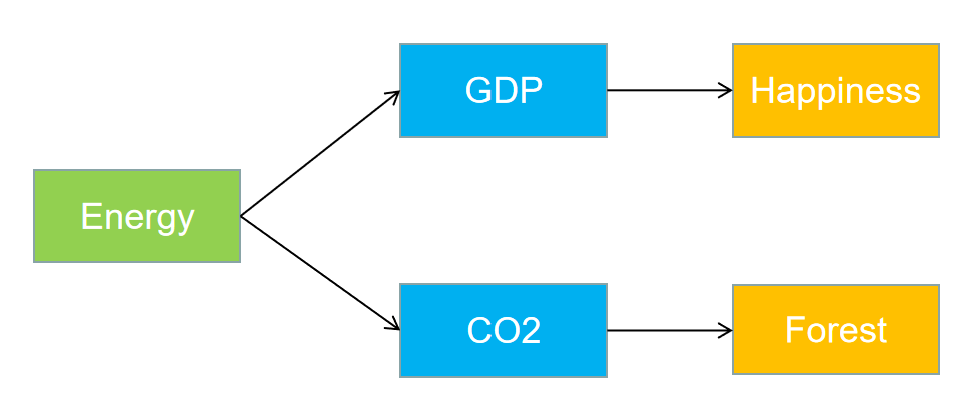

```python
from IPython.display import Image
Image(filename="D:/g.png", width=500, height=200)
```

#### - The diagram from schema DB is similar as the original planed chart above.

#### - Because the original data for forest is just the total forest area, not the forest area per capita, so we also input the data population to calculate the forest area per capita.

#### - All the data sets are linked with the same variable "Country_name" and "year" as FOREIGN KEY.

# 4. Analysis the extracted data from DB

## 4.1 Energy Consumption per Capita (2010-2020) of 10 Selected Countries

```python
sql_statement = """
                SELECT
                Country_name,
                year,
                Energy_consumption_per_capita
                FROM energy2010to2020
                WHERE Country_name IN ("Australia", "New Zealand", "United States", "Brazil", "Germany",
                     "Finland", "South Africa", "Israel", "China", "India");
                """
Energy10=pd.read_sql_query(sql_statement, connection)
Energy10
```

|  | Country_name | year | Energy_consumption_per_capita |
| --- | --- | --- | --- |
| 0 | Australia | 2010 | 240.5 |
| 1 | Australia | 2011 | 243.3 |
| 2 | Australia | 2012 | 236.5 |
| 3 | Australia | 2013 | 235.9 |
| 4 | Australia | 2014 | 234.8 |
| ... | ... | ... | ... |
| 105 | United States | 2016 | 284.7 |
| 106 | United States | 2017 | 283.8 |
| 107 | United States | 2018 | 292.4 |
| 108 | United States | 2019 | 288.4 |
| 109 | United States | 2020 | 265.2 |

110 rows × 3 columns

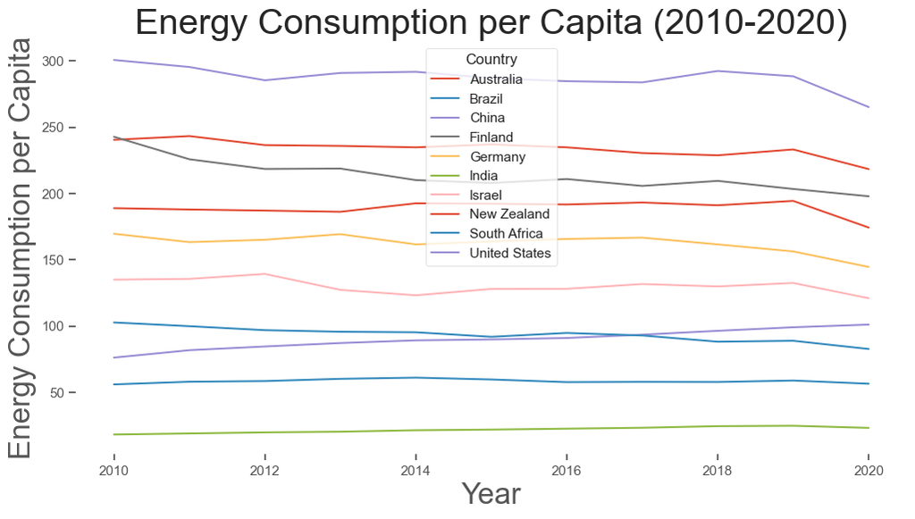

```python
plt.figure(figsize=(12, 6))
for country in Energy10['Country_name'].unique():
    country_data = Energy10[Energy10['Country_name'] == country]
    plt.plot(country_data['year'], country_data['Energy_consumption_per_capita'], label=country)
plt.xlabel('Year')
plt.ylabel('Energy Consumption per Capita')
plt.title('Energy Consumption per Capita (2010-2020)')
plt.legend(title='Country')
plt.grid(True)
plt.show()
```

#### From above chart, we can find that:

- From 2010 to 2020, for most the countries we can find the relative stable trend.
- There is an obvious decrease from 2019 to 2020, which was mainly caused by Covid in 2020.
- United States, Australia, Finland, New Zealand are ranking top 4 as developed countries. Developing countries such like South Africa, China, Bazil, Indian have relative smaller energy consumption per capita.

## 4.2 Average Energy Consumption per Capita (2010-2020) and Ranking

```python
sql_statement = """
                SELECT
                    Country_name,
                    ROUND(AVG(Energy_consumption_per_capita), 1) AS AverageEnergyConsumptionPerCapita
                FROM
                    energy2010to2020
                WHERE
                    Country_name IN ("Australia", "New Zealand", "United States", "Brazil", "Germany",
                                     "Finland", "South Africa", "Israel", "China", "India")
                    AND year BETWEEN 2010 AND 2020
                GROUP BY
                    Country_name
                ORDER BY
                    AverageEnergyConsumptionPerCapita DESC;
                """

Energy_10 = pd.read_sql_query(sql_statement, connection)
print(Energy_10)
```

```
    Country_name  AverageEnergyConsumptionPerCapita
0  United States                              287.8
1      Australia                              234.0
2        Finland                              213.8
3    New Zealand                              189.1
4        Germany                              162.5
5         Israel                              130.1
6   South Africa                               93.6
7          China                               90.0
8         Brazil                               58.4
9          India                               21.7
```

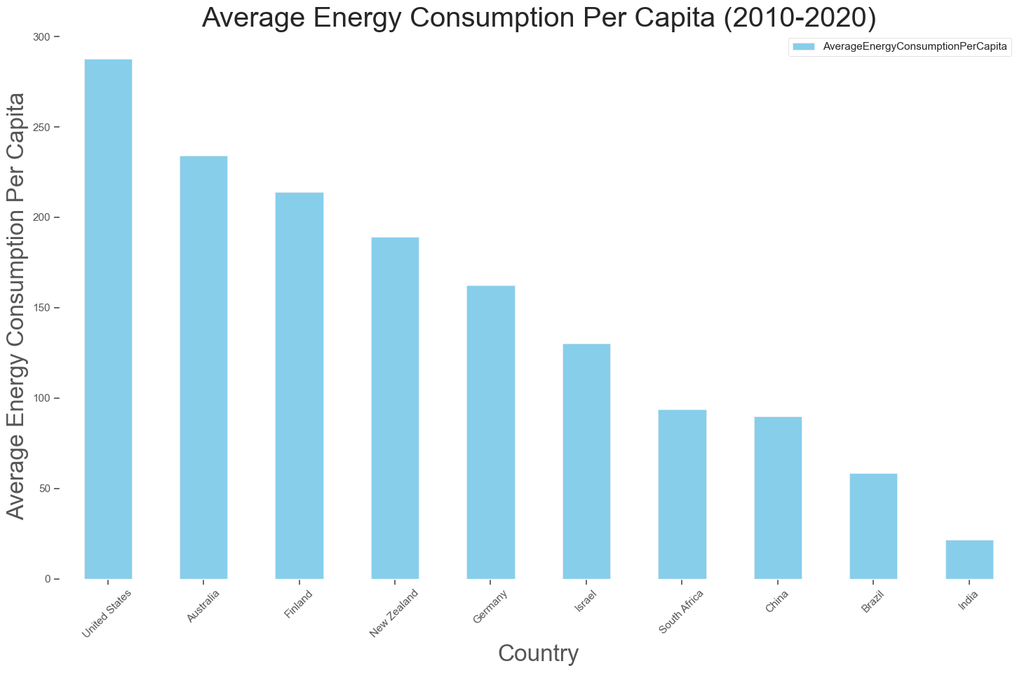

```python
plt.figure(figsize=(10, 6))
Energy_10.plot(kind='bar', x='Country_name', y='AverageEnergyConsumptionPerCapita', color='skyblue')
plt.title('Average Energy Consumption Per Capita (2010-2020)')
plt.xlabel('Country')
plt.ylabel('Average Energy Consumption Per Capita')
plt.xticks(rotation=45)
plt.tight_layout()
plt.show()
```

#### From above chart on average from 2010 to 2020, we can find that:

- United States, Australia and Finland as developed countries have the highest energy consumption per capita;
- Indian is relative low from this side. We see big difference there.

## 4.3 GDP per Capita (2010-2020) of 10 Selected Countries

```python
sql_statement = """
                SELECT
                Country_name,
                year,
                GDP_per_capita
                FROM worldbank_gdp
                WHERE Country_name IN ("Australia", "New Zealand", "United States", "Brazil", "Germany",
                     "Finland", "South Africa", "Israel", "China", "India");
                """
GDP10=pd.read_sql_query(sql_statement, connection)
GDP10
```

|  | Country_name | year | GDP_per_capita |
| --- | --- | --- | --- |
| 0 | Australia | 2010 | 52147.024194 |
| 1 | Australia | 2011 | 62609.660716 |
| 2 | Australia | 2012 | 68078.044228 |
| 3 | Australia | 2013 | 68198.419345 |
| 4 | Australia | 2014 | 62558.243879 |
| ... | ... | ... | ... |
| 105 | United States | 2016 | 57866.744934 |
| 106 | United States | 2017 | 59907.754261 |
| 107 | United States | 2018 | 62823.309438 |
| 108 | United States | 2019 | 65120.394663 |
| 109 | United States | 2020 | 63528.634303 |

110 rows × 3 columns

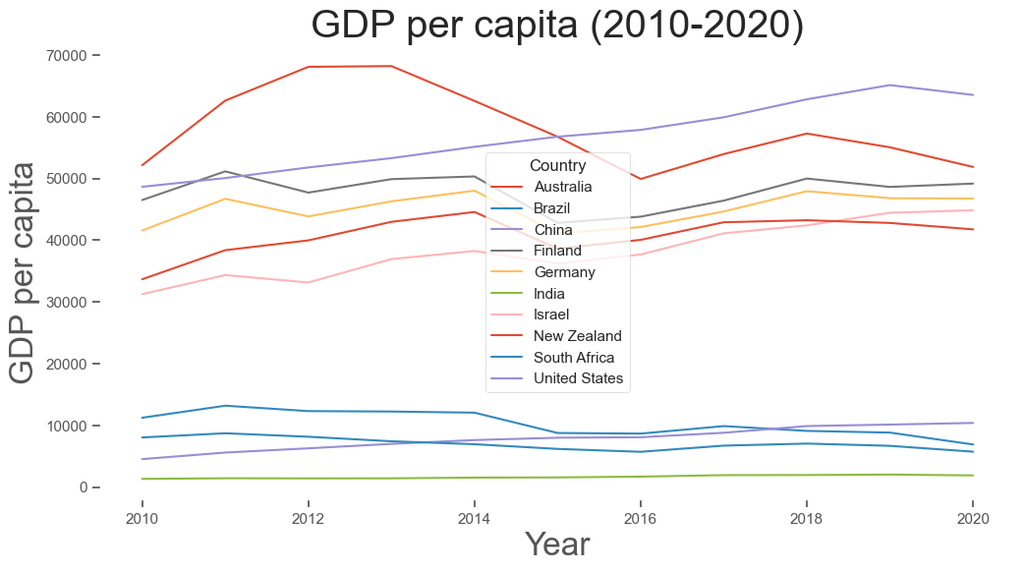

```python
plt.figure(figsize=(12, 6))
for country in GDP10['Country_name'].unique():
    country_data = GDP10[GDP10['Country_name'] == country]
    plt.plot(country_data['year'], country_data['GDP_per_capita'], label=country)
plt.xlabel('Year')
plt.ylabel('GDP per capita')
plt.title('GDP per capita (2010-2020)')
plt.legend(title='Country')
plt.grid(True)
plt.show()
```

## 4.4 Average GDP per Capita (2010-2020) and GDP Efficiency based on Eenergy

```python
sql_statement = """
                SELECT
                    Country_name,
                    ROUND(AVG(GDP_per_capita)/1000, 1) AS AverageGDPperCapita
                FROM
                    worldbank_gdp
                WHERE
                    Country_name IN ("Australia", "New Zealand", "United States", "Brazil", "Germany",
                                     "Finland", "South Africa", "Israel", "China", "India")
                    AND year BETWEEN 2010 AND 2020
                GROUP BY
                    Country_name
                ORDER BY
                    AverageGDPperCapita DESC;
                """
GDP_10 = pd.read_sql_query(sql_statement, connection)
print(GDP_10)
```

```
    Country_name  AverageGDPperCapita
0      Australia                 58.0
1  United States                 56.8
2        Finland                 47.9
3        Germany                 45.1
4    New Zealand                 40.8
5         Israel                 38.2
6         Brazil                 10.3
7          China                  7.9
8   South Africa                  7.1
9          India                  1.7
```

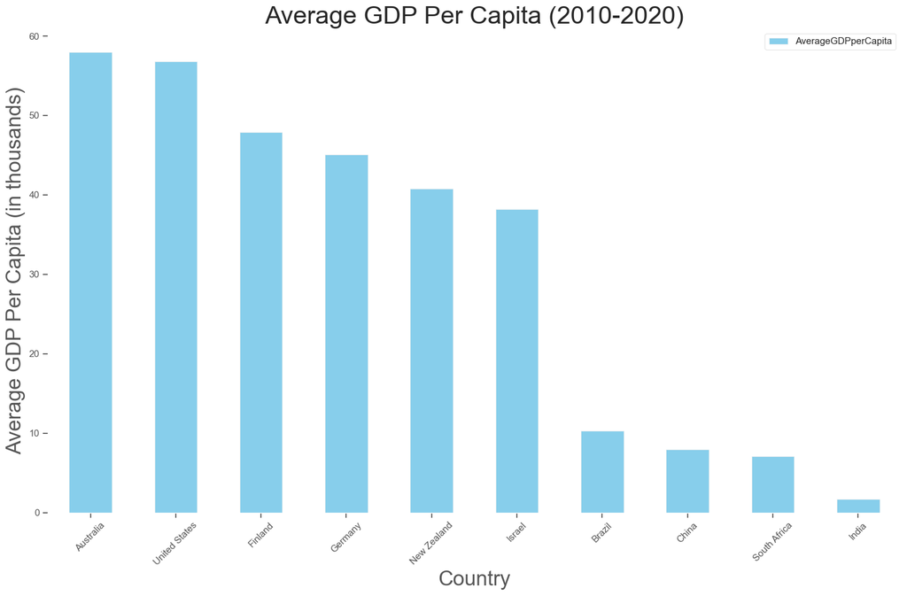

```python
plt.figure(figsize=(10, 6))
GDP_10.plot(kind='bar', x='Country_name', y='AverageGDPperCapita', color='skyblue')
plt.title('Average GDP Per Capita (2010-2020)')
plt.xlabel('Country')
plt.ylabel('Average GDP Per Capita (in thousands)')
plt.xticks(rotation=45)
plt.tight_layout()
plt.show()
```

#### From above chart on average from 2010 to 2020, we can find that:

- Australia, United States, Finland, Germany, New Zealand and Israel which represent developed countries have high GPD per capita.
- Developing countries such like Bazil, China, South Africa and Indian are relative smaller.

```python
merged_df = pd.merge(Energy_10, GDP_10, on='Country_name')
merged_df
```

|  | Country_name | AverageEnergyConsumptionPerCapita | AverageGDPperCapita |
| --- | --- | --- | --- |
| 0 | United States | 287.8 | 56.8 |
| 1 | Australia | 234.0 | 58.0 |
| 2 | Finland | 213.8 | 47.9 |
| 3 | New Zealand | 189.1 | 40.8 |
| 4 | Germany | 162.5 | 45.1 |
| 5 | Israel | 130.1 | 38.2 |
| 6 | South Africa | 93.6 | 7.1 |
| 7 | China | 90.0 | 7.9 |
| 8 | Brazil | 58.4 | 10.3 |
| 9 | India | 21.7 | 1.7 |

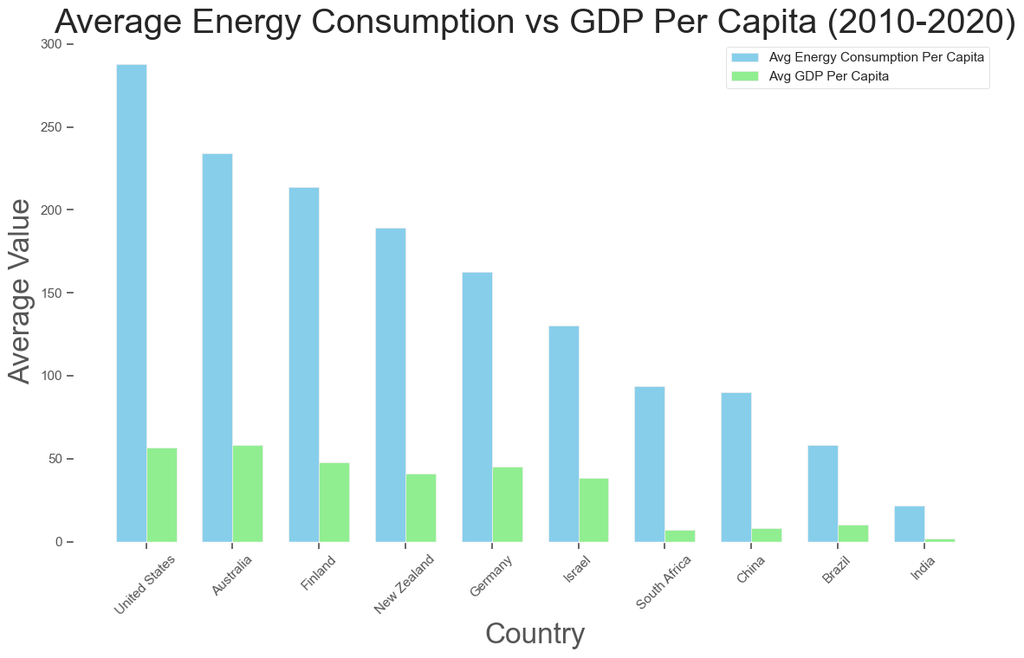

```python
bar_width = 0.35
positions = np.arange(len(merged_df))
plt.figure(figsize=(12, 8))
plt.bar(positions - bar_width/2, merged_df['AverageEnergyConsumptionPerCapita'], width=bar_width, color='skyblue', label='Avg Energy Consumption Per Capita')
plt.bar(positions + bar_width/2, merged_df['AverageGDPperCapita'], width=bar_width, color='lightgreen', label='Avg GDP Per Capita')
plt.title('Average Energy Consumption vs GDP Per Capita (2010-2020)')
plt.xlabel('Country')
plt.ylabel('Average Value')
plt.xticks(positions, merged_df['Country_name'], rotation=45)
plt.legend()
plt.tight_layout()
plt.show()
```

#### From above Chart, we find that:

- Normally the higher energy consumption per capita, the higher the GDP per capita. But the gaps between the energy consumption per capita and GDP per capita of South Africa, China, Brazil and Indian are big. That means for sames amount of energy consumption, therse countries produce less GDP.

## 4.5 CO2 per Capita (2010-2020)

```python
sql_statement = """
                SELECT
                Country_name,
                year,
                CO2_per_capita
                FROM worldbank_CO2
                WHERE Country_name IN ("Australia", "New Zealand", "United States", "Brazil", "Germany",
                     "Finland", "South Africa", "Israel", "China", "India");
                """
CO210=pd.read_sql_query(sql_statement, connection)
CO210
```

|  | Country_name | year | CO2_per_capita |
| --- | --- | --- | --- |
| 0 | Australia | 2010 | 17.973752 |
| 1 | Australia | 2011 | 17.656055 |
| 2 | Australia | 2012 | 17.405618 |
| 3 | Australia | 2013 | 16.794588 |
| 4 | Australia | 2014 | 16.155745 |
| ... | ... | ... | ... |
| 105 | United States | 2016 | 15.149883 |
| 106 | United States | 2017 | 14.823245 |
| 107 | United States | 2018 | 15.222518 |
| 108 | United States | 2019 | 14.673381 |
| 109 | United States | 2020 | 13.032828 |

110 rows × 3 columns

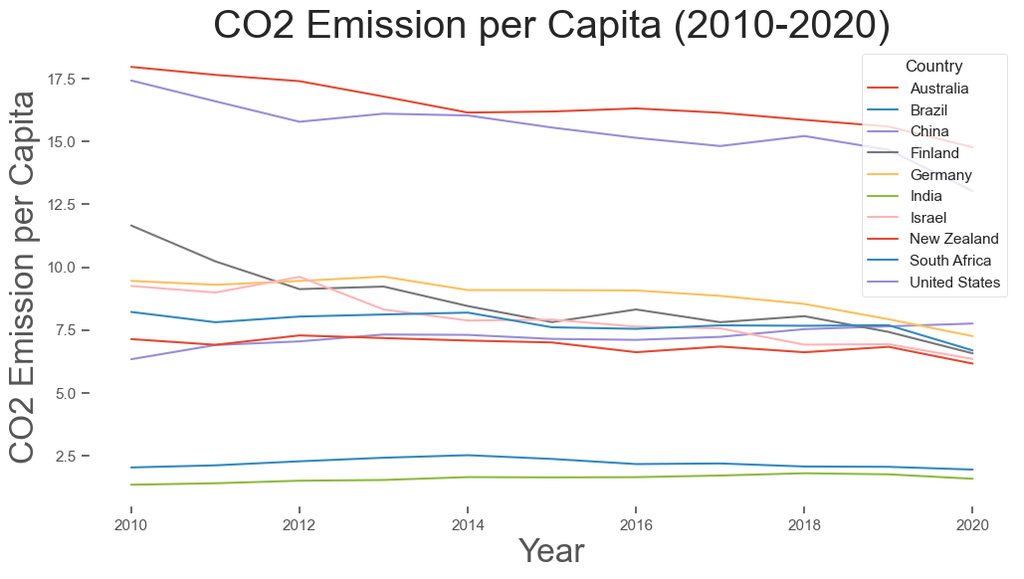

```python
plt.figure(figsize=(12, 6))
for country in CO210['Country_name'].unique():
    country_data = CO210[CO210['Country_name'] == country]
    plt.plot(country_data['year'], country_data['CO2_per_capita'], label=country)
plt.xlabel('Year')
plt.ylabel('CO2 Emission per Capita')
plt.title('CO2 Emission per Capita (2010-2020)')
plt.legend(title='Country')
plt.grid(True)
plt.show()
```

#### From above chart, we can find that:

- Australia and United States have high CO2 emission per capita, but have big derease from 2010 to 2020.
- Finland, Israel and Germany have middle CO2 emission per capita, and also have big derease from 2010 to 2020. China has some increase along the years. Other countries are relative stable.
- Indian and Brazil have low CO2 emission per capita as developing countries.

## 4.6 Average CO2 per Capita (2010-2020) and CO2 Emission based on Energy

```python
sql_statement = """
                SELECT
                    Country_name,
                    ROUND(AVG(CO2_per_capita), 1) AS AverageCO2perCapita
                FROM
                    worldbank_CO2
                WHERE
                    Country_name IN ("Australia", "New Zealand", "United States", "Brazil", "Germany",
                                     "Finland", "South Africa", "Israel", "China", "India")
                    AND year BETWEEN 2010 AND 2020
                GROUP BY
                    Country_name
                ORDER BY
                     AverageCO2perCapita DESC;
                """

CO2_10 = pd.read_sql_query(sql_statement, connection)
print(CO2_10)
```

```
    Country_name  AverageCO2perCapita
0      Australia                 16.4
1  United States                 15.5
2        Germany                  8.9
3        Finland                  8.6
4         Israel                  7.9
5   South Africa                  7.7
6          China                  7.2
7    New Zealand                  6.9
8         Brazil                  2.2
9          India                  1.6
```

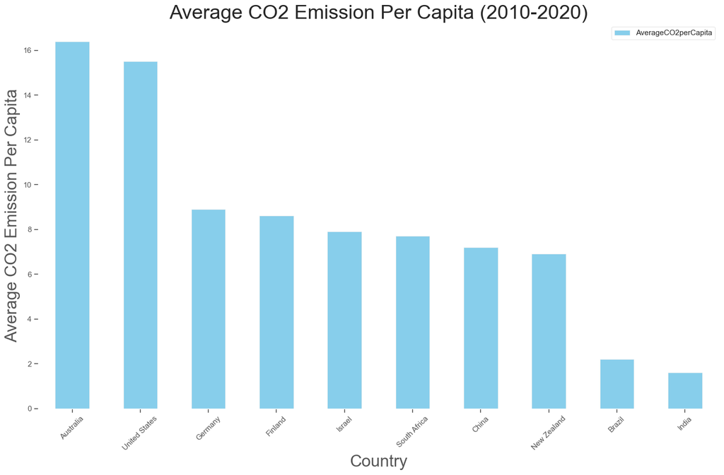

```python
plt.figure(figsize=(10, 6))
CO2_10.plot(kind='bar', x='Country_name', y='AverageCO2perCapita', color='skyblue')
plt.title('Average CO2 Emission Per Capita (2010-2020)')
plt.xlabel('Country')
plt.ylabel('Average CO2 Emission Per Capita')
plt.xticks(rotation=45)
plt.tight_layout()
plt.show()
```

#### From above chart on average from 2010 t0 2020, we can find that:

- Australia and United States have high CO2 emission per capita;
- Germany, Finland, Israel, South Africa, China and New Zealand have similar level without big gap between each other;
- Brazil and Indian have lowest CO2 emission per capita;

```python
merged_df = pd.merge(Energy_10, CO2_10, on='Country_name')
merged_df
```

|  | Country_name | AverageEnergyConsumptionPerCapita | AverageCO2perCapita |
| --- | --- | --- | --- |
| 0 | United States | 287.8 | 15.5 |
| 1 | Australia | 234.0 | 16.4 |
| 2 | Finland | 213.8 | 8.6 |
| 3 | New Zealand | 189.1 | 6.9 |
| 4 | Germany | 162.5 | 8.9 |
| 5 | Israel | 130.1 | 7.9 |
| 6 | South Africa | 93.6 | 7.7 |
| 7 | China | 90.0 | 7.2 |
| 8 | Brazil | 58.4 | 2.2 |
| 9 | India | 21.7 | 1.6 |

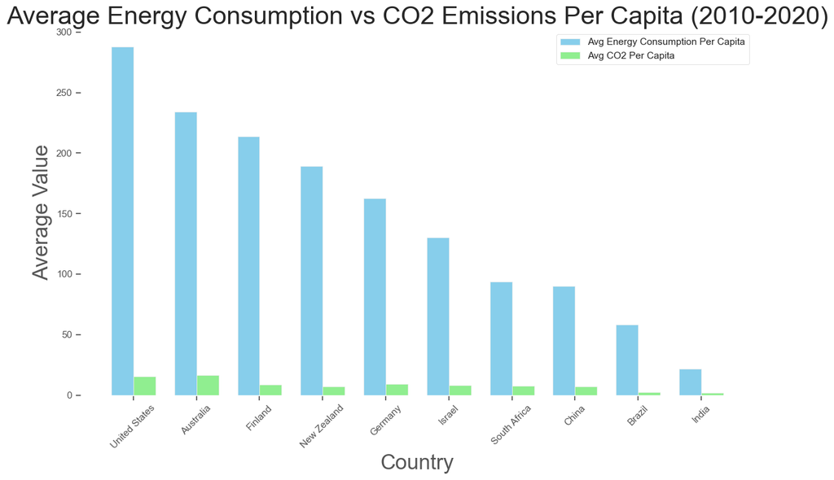

```python
bar_width = 0.35
positions = np.arange(len(merged_df))
plt.figure(figsize=(12, 8))
plt.bar(positions - bar_width/2, merged_df['AverageEnergyConsumptionPerCapita'], width=bar_width, color='skyblue', label='Avg Energy Consumption Per Capita')
plt.bar(positions + bar_width/2, merged_df['AverageCO2perCapita'], width=bar_width, color='lightgreen', label='Avg CO2 Per Capita')
plt.title('Average Energy Consumption vs CO2 Emissions Per Capita (2010-2020)')
plt.xlabel('Country')
plt.ylabel('Average Value')
plt.xticks(positions, merged_df['Country_name'], rotation=45)
plt.legend()
plt.tight_layout()
plt.show()
```

#### From above Chart, we find that:

- United States has the highest energy consumption per capita, but also high CO2 emission per capita. Other countries generally folllow the corelationship.

## 4.7 Forest per Capita (2010-2020)

```python
sql_statement = """
                SELECT
                Country_name,
                year,
                ForestArea
                FROM worldbank_forest
                WHERE Country_name IN ("Australia", "New Zealand", "United States", "Brazil", "Germany",
                     "Finland", "South Africa", "Israel", "China", "India");
                """
Forest_10=pd.read_sql_query(sql_statement, connection)
Forest_10
```

|  | Country_name | year | ForestArea |
| --- | --- | --- | --- |
| 0 | Australia | 2010 | 1295461.0 |
| 1 | Australia | 2011 | 1302557.8 |
| 2 | Australia | 2012 | 1309654.6 |
| 3 | Australia | 2013 | 1316751.4 |
| 4 | Australia | 2014 | 1323848.2 |
| ... | ... | ... | ... |
| 105 | United States | 2016 | 3100950.0 |
| 106 | United States | 2017 | 3097950.0 |
| 107 | United States | 2018 | 3097950.0 |
| 108 | United States | 2019 | 3097950.0 |
| 109 | United States | 2020 | 3097950.0 |

110 rows × 3 columns

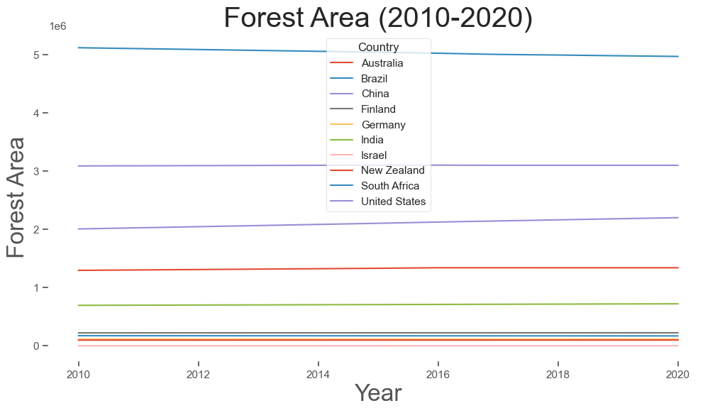

```python
plt.figure(figsize=(12, 6))
for country in Forest_10['Country_name'].unique():
    country_data = Forest_10[Forest_10['Country_name'] == country]
    plt.plot(country_data['year'], country_data['ForestArea'], label=country)
plt.xlabel('Year')
plt.ylabel('Forest Area')
plt.title('Forest Area (2010-2020)')
plt.legend(title='Country')
plt.grid(True)
plt.show()
```

#### From above chart, we can find that:

- Brazil have the largest forest area, but have relatively big derease from 2010 to 2020.
- United States is ranking number 2 with stable forest area. China is ranking number 3 and good increase of the forest area from 2010 to 2020.
- Other countries are relatively stable.

```python
sql_statement = """
                SELECT
                Country_name,
                year,
                Population
                FROM worldbank_population
                WHERE Country_name IN ("Australia", "New Zealand", "United States", "Brazil", "Germany",
                     "Finland", "South Africa", "Israel", "China", "India");
                """
Population_10=pd.read_sql_query(sql_statement, connection)
Population_10
```

|  | Country_name | year | Population |
| --- | --- | --- | --- |
| 0 | Australia | 2010 | 22031750.0 |
| 1 | Australia | 2011 | 22340024.0 |
| 2 | Australia | 2012 | 22733465.0 |
| 3 | Australia | 2013 | 23128129.0 |
| 4 | Australia | 2014 | 23475686.0 |
| ... | ... | ... | ... |
| 105 | United States | 2016 | 323071755.0 |
| 106 | United States | 2017 | 325122128.0 |
| 107 | United States | 2018 | 326838199.0 |
| 108 | United States | 2019 | 328329953.0 |
| 109 | United States | 2020 | 331511512.0 |

110 rows × 3 columns

```python
Forest_Per_Capita= pd.merge(Forest_10, Population_10, on=['Country_name', 'year'])
Forest_Per_Capita['ForestPerCapita'] = Forest_Per_Capita['ForestArea']*1000 /Forest_Per_Capita['Population']
Forest_Per_Capita
```

|  | Country_name | year | ForestArea | Population | ForestPerCapita |
| --- | --- | --- | --- | --- | --- |
| 0 | Australia | 2010 | 1295461.0 | 22031750.0 | 58.799732 |
| 1 | Australia | 2011 | 1302557.8 | 22340024.0 | 58.306016 |
| 2 | Australia | 2012 | 1309654.6 | 22733465.0 | 57.609106 |
| 3 | Australia | 2013 | 1316751.4 | 23128129.0 | 56.932898 |
| 4 | Australia | 2014 | 1323848.2 | 23475686.0 | 56.392312 |
| ... | ... | ... | ... | ... | ... |
| 105 | United States | 2016 | 3100950.0 | 323071755.0 | 9.598332 |
| 106 | United States | 2017 | 3097950.0 | 325122128.0 | 9.528573 |
| 107 | United States | 2018 | 3097950.0 | 326838199.0 | 9.478543 |
| 108 | United States | 2019 | 3097950.0 | 328329953.0 | 9.435478 |
| 109 | United States | 2020 | 3097950.0 | 331511512.0 | 9.344924 |

110 rows × 5 columns

```python
average_forest_per_capita = Forest_Per_Capita.groupby('Country_name')['ForestPerCapita'].mean().reset_index()
average_forest_per_capita
```

|  | Country_name | ForestPerCapita |
| --- | --- | --- |
| 0 | Australia | 55.695227 |
| 1 | Brazil | 24.595366 |
| 2 | China | 1.526201 |
| 3 | Finland | 40.923702 |
| 4 | Germany | 1.395612 |
| 5 | India | 0.536528 |
| 6 | Israel | 0.180578 |
| 7 | New Zealand | 21.225550 |
| 8 | South Africa | 3.117746 |
| 9 | United States | 9.666301 |

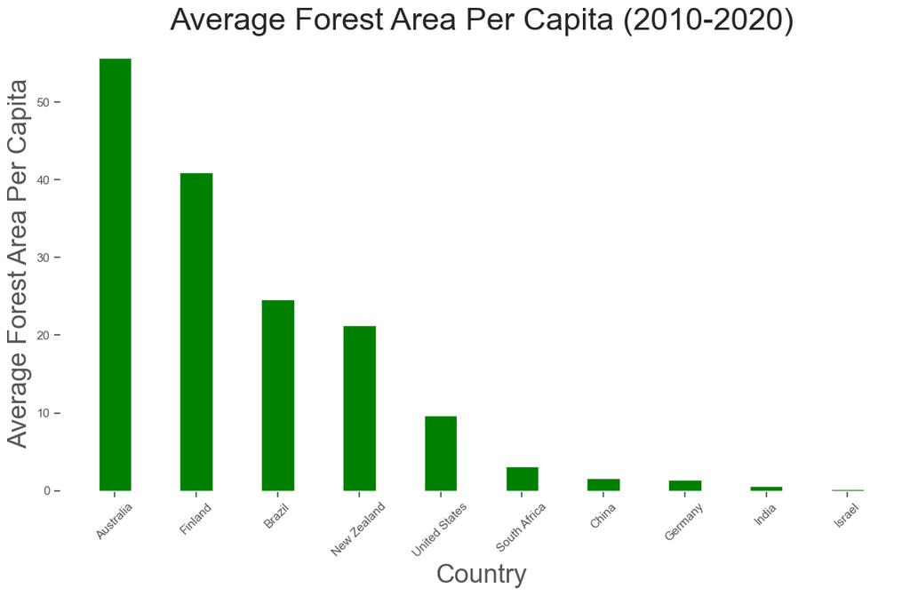

```python
bar_width = 0.4
average_forest_per_capita_sorted = average_forest_per_capita.sort_values(by='ForestPerCapita', ascending=False)
plt.figure(figsize=(12, 8))
plt.bar(average_forest_per_capita_sorted['Country_name'], average_forest_per_capita_sorted['ForestPerCapita'], color='green', width=bar_width)
plt.title('Average Forest Area Per Capita (2010-2020)')
plt.xlabel('Country')
plt.ylabel('Average Forest Area Per Capita')
plt.xticks(rotation=45)
plt.tight_layout()
plt.show()
```

#### From above chart, we can find that:

- Australia and Finaland have very high forest area per captia.
- Indian and Israel are very low in this area. Israel is mainly caused by its geographic situation.

```python
merged_df = pd.merge(CO2_10, average_forest_per_capita, on='Country_name')
merged_df
```

|  | Country_name | AverageCO2perCapita | ForestPerCapita |
| --- | --- | --- | --- |
| 0 | Australia | 16.4 | 55.695227 |
| 1 | United States | 15.5 | 9.666301 |
| 2 | Germany | 8.9 | 1.395612 |
| 3 | Finland | 8.6 | 40.923702 |
| 4 | Israel | 7.9 | 0.180578 |
| 5 | South Africa | 7.7 | 3.117746 |
| 6 | China | 7.2 | 1.526201 |
| 7 | New Zealand | 6.9 | 21.225550 |
| 8 | Brazil | 2.2 | 24.595366 |
| 9 | India | 1.6 | 0.536528 |

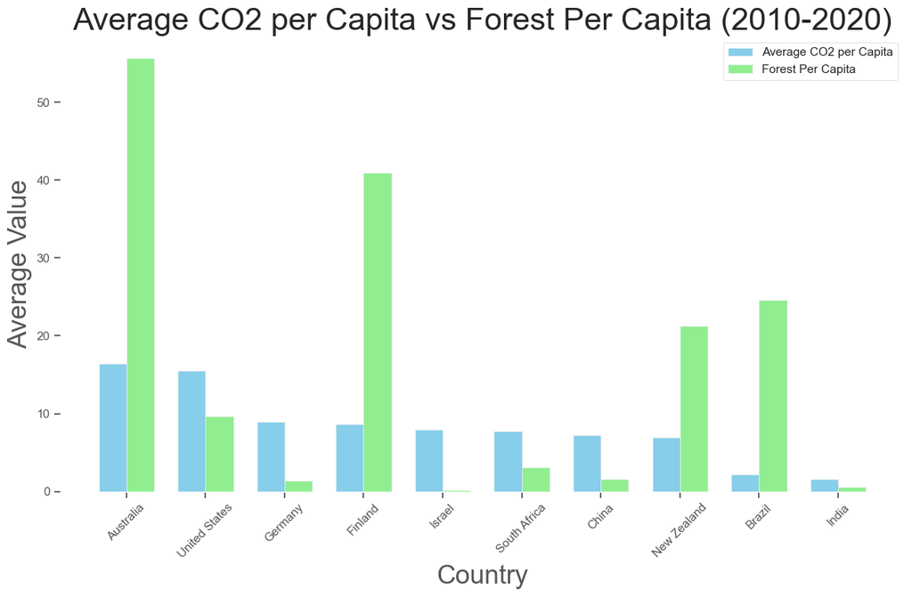

```python
bar_width = 0.35
positions = np.arange(len(merged_df))
plt.figure(figsize=(12, 8))
plt.bar(positions - bar_width/2, merged_df['AverageCO2perCapita'], width=bar_width, color='skyblue', label='Average CO2 per Capita')
plt.bar(positions + bar_width/2, merged_df['ForestPerCapita'], width=bar_width, color='lightgreen', label='Forest Per Capita')
plt.title('Average CO2 per Capita vs Forest Per Capita (2010-2020)')
plt.xlabel('Country')
plt.ylabel('Average Value')
plt.xticks(positions, merged_df['Country_name'], rotation=45)
plt.legend()
plt.tight_layout()
plt.show()
```

#### From above Chart, we find that:

- Although Australia has the highest CO2 emission per capita, it has also very high forest area per capita to conpensate this influence. Same as Finland, New Zealand and Brazil.
- Germany, Israel, South Afica and China are on the opposite.

# 5. Create DB Views which encapsulated queries and test them

```python
%load_ext sql
```

```
The sql extension is already loaded. To reload it, use:
  %reload_ext sql
```

## 5.1 CREATE VIEW NewZealand_happiness

```python
%%sql sqlite:///C:/Users/lpxue/datasets/mySQLiteDB.sl3
CREATE VIEW NewZealand_happiness AS
    SELECT Country_name, year, Life_ladder
    FROM (SELECT
                Country_name,
                year,
                Life_ladder
                FROM happiness)
    WHERE Country_name = 'New Zealand';
```

[output not shown]

```python
%%sql
SELECT *
FROM NewZealand_happiness
```

```
 * sqlite:///C:/Users/lpxue/datasets/mySQLiteDB.sl3
Done.
```

| Country_name | year | Life_ladder |
| --- | --- | --- |
| New Zealand | 2006 | 7.305014133453369 |
| New Zealand | 2007 | 7.604173183441162 |
| New Zealand | 2008 | 7.381170749664307 |
| New Zealand | 2010 | 7.223756313323975 |
| New Zealand | 2011 | 7.190638065338135 |
| New Zealand | 2012 | 7.249629974365234 |
| New Zealand | 2013 | 7.280151844024658 |
| New Zealand | 2014 | 7.305892467498779 |
| New Zealand | 2015 | 7.418120861053467 |
| New Zealand | 2016 | 7.225687980651855 |
| New Zealand | 2017 | 7.327182769775391 |
| New Zealand | 2018 | 7.370285987854004 |
| New Zealand | 2019 | 7.205174446105957 |
| New Zealand | 2020 | 7.257381916046143 |

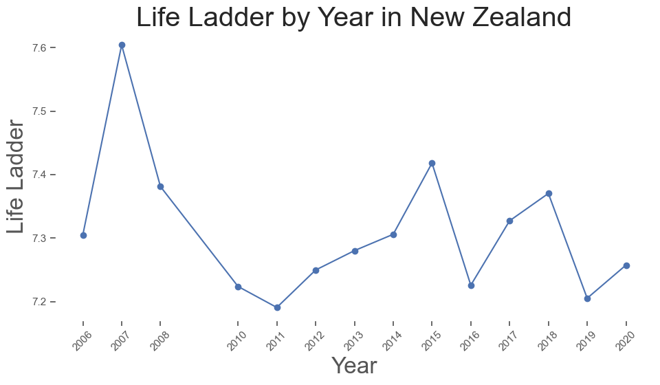

```python
from sqlalchemy import create_engine
engine = create_engine('sqlite:///C:/Users/lpxue/datasets/mySQLiteDB.sl3')
query = "SELECT year, Life_ladder FROM NewZealand_happiness"
NewZealand_happiness = pd.read_sql(query, engine)
plt.figure(figsize=(10, 6))
plt.plot(NewZealand_happiness['year'], NewZealand_happiness['Life_ladder'], marker='o', linestyle='-', color='b')
plt.title('Life Ladder by Year in New Zealand')
plt.xlabel('Year')
plt.ylabel('Life Ladder')
plt.grid(True)
plt.xticks(NewZealand_happiness['year'], rotation=45)
plt.tight_layout()
plt.show()
```

## 5.2 CREATE VIEW high_happiness_countries_in_2020

```python
%%sql sqlite:///C:/Users/lpxue/datasets/mySQLiteDB.sl3
CREATE VIEW high_happiness_countries_in2020 AS
    SELECT Country_name, year, Life_ladder
    FROM (SELECT
                Country_name,
                year,
                Life_ladder
                FROM happiness
                ORDER BY Life_ladder DESC
         )
    WHERE Life_ladder > 7 AND year = 2020;
```

[output not shown]

```python
%%sql
SELECT *
FROM high_happiness_countries_in2020
```

```
 * sqlite:///C:/Users/lpxue/datasets/mySQLiteDB.sl3
Done.
```

| Country_name | year | Life_ladder |
| --- | --- | --- |
| Finland | 2020 | 7.889349937438965 |
| Iceland | 2020 | 7.575489521026611 |
| Denmark | 2020 | 7.514631271362305 |
| Switzerland | 2020 | 7.508435249328613 |
| Netherlands | 2020 | 7.504447937011719 |
| Sweden | 2020 | 7.314341068267822 |
| Germany | 2020 | 7.311897754669189 |
| Norway | 2020 | 7.290032386779785 |
| New Zealand | 2020 | 7.257381916046143 |
| Austria | 2020 | 7.213489055633545 |
| Israel | 2020 | 7.194928169250488 |
| Australia | 2020 | 7.137367725372314 |
| Ireland | 2020 | 7.03493070602417 |
| United States | 2020 | 7.028088092803955 |
| Canada | 2020 | 7.024904727935791 |

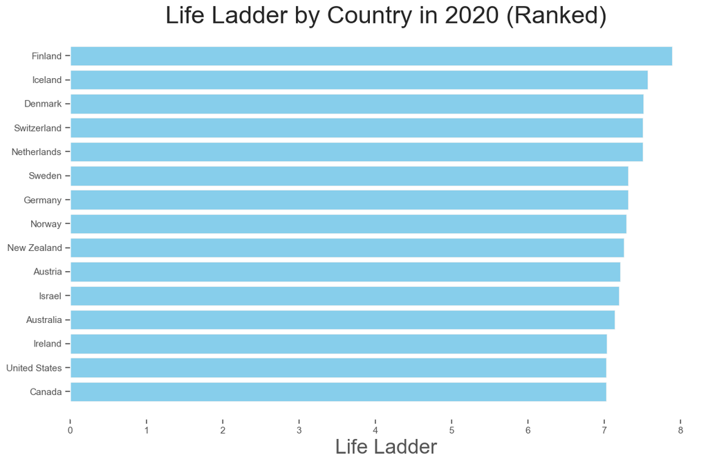

```python
engine = create_engine('sqlite:///C:/Users/lpxue/datasets/mySQLiteDB.sl3')
query = "SELECT Country_name, Life_ladder FROM high_happiness_countries_in2020"
high_happiness_countries_in_2020 = pd.read_sql(query, engine)
plt.figure(figsize=(12, 8))
plt.barh(high_happiness_countries_in_2020['Country_name'], high_happiness_countries_in_2020['Life_ladder'], color='skyblue')
plt.xlabel('Life Ladder')
plt.title('Life Ladder by Country in 2020 (Ranked)')
plt.gca().invert_yaxis()  # Invert y-axis to rank from highest to lowest
plt.grid(axis='x')
plt.tight_layout()
plt.show()
```

#### From above Chart, we find that in 2020:

- The happinest country is Finland. New Zealand is ranking number 9.